# Prob2

2024-06-06

## Part A

We start by reading and visualizing the data. We are in a contest of paired data (same CDs) and we want to test if the prices and conditions of the CDs are different.

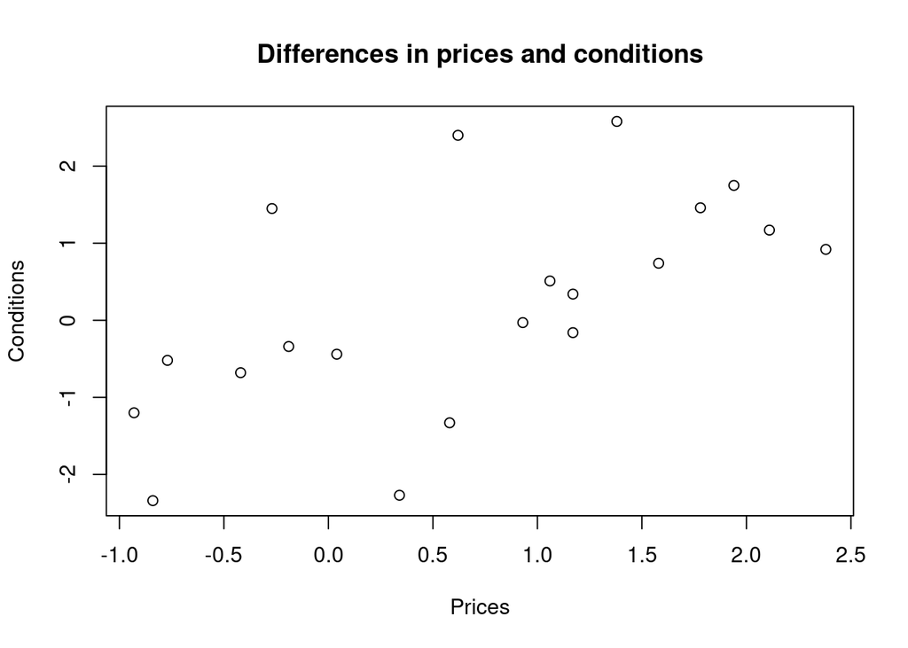

We will perform the test and then at point b) we will verify assumptions.

```r
x.mean = colMeans(diff)
S = cov(diff)
n = 20
p = 2
alpha = 0.05
cfr.fisher = (n-1)*p/(n-p)*qf(1-alpha, p, n-p)
T2 = n*(x.mean %*% solve(S) %*% x.mean)
T2>cfr.fisher
```

```
##      [,1]
## [1,] TRUE
```

```r
p_value = 1 - pf(T2*(n-p)/p/(n-1), p, n-p)
p_value
```

```
##              [,1]
## [1,] 1.958766e-12
```

The null hypothesis is rejected. The prices and conditions of the CDs are different. In particular we can see that the differncenes in condition and in price are both positive: it means that if you want to buy a CD in a better condition you will have to pay more, and it is best if you go at store discomaniac. If you wanto to save money you can go to the store lipstick.

## Part B

We need to test the multivariate normality of the dataset of the differeces. We can see that the assumption is met.

```r
library(MVN)
mvn(diff)$multivariateNormality
```

```
##            Test        HZ   p value MVN
## 1 Henze-Zirkler 0.5535753 0.1778252 YES
```

```r
# The assumption of multivariate normality is met.
```

## Part C

We will plot the data and the confidence ellipse. As we can see the point c(0, 0) is not contained in the ellipse (it is so far that is not possible to see it in the graph neither)

```r
# c)
library(car)
```

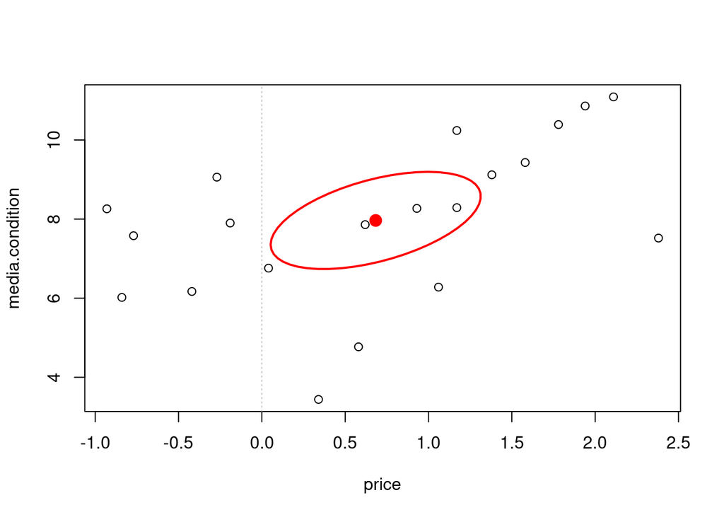

```r
plot(diff)
ellipse(center = x.mean, shape = S/n, radius = sqrt(cfr.fisher), col = "red")
abline(h = 0, lty = 3, col=  "gray")
abline(v = 0, lty = 3, col=  "gray")
```

```r
# d)
```

## Part D

Bonferroni simultaneous confidence intervals for the means.

```r
alpha = 0.05
k = 4

BCI_means = cbind(
  inf = x.mean - qt(1-alpha/2/k, n-1)*sqrt(diag(solve(S))/n),
  center = x.mean,
  sup = x.mean + qt(1-alpha/2/k, n-1)*sqrt(diag(solve(S))/n)
)
BCI_means
```

```
##                          inf center      sup
## price           -0.007848718 0.6830 1.373849
## media.condition  7.611114451 7.9655 8.319886
```

```r
BCI_var = cbind(
  inf = (n - 1) * diag(S) / qchisq(1 - alpha/(2*k), n - 1),
  center = diag(S) ,
  sup = (n - 1) * diag(S) / qchisq(alpha/(2*k), n - 1)
)
BCI_var
```

```
##                       inf   center       sup
## price           0.5322847 1.059612  2.841861
## media.condition 2.0228229 4.026805 10.799827
```